# Modeling and prediction for movies

## Setup

### Load packages

```r
library(statsr)
library(tidyverse)
library(ggplot2)
library(GGally)
```

### Load data

```r
load("movies.Rdata")
```

## Part 1: Data

This dataset includes information from Rotten Tomatoes and IMDB for a random sample of movies. And the dataset is comprised of 651 randomly sampled movies produced and released before 2016. Observations in the sample are collected by random sampling method. Therefore we can generalize the result.

However there is no random assignment. It is not experiment but observational study. Therefore we can not assume that there is causality.

And data were collected from someone who want to answer the questions. Therefore there can be some bias.

## Part 2: Research question

As a data scientist at Paramount Pictures, I would like to figure out what valuables have strong relationship with audience_score in the data set. And I would like to predict the audience_score when new movie introduced.

## Part 3: Exploratory data analysis

**Check dimension**

```r
dim(movies)
```

```
## [1] 651  32
```

There are 651 observations(movies) and 32 variables.

**Check structure**

```r
str(movies)
```

```
## tibble [651 x 32] (S3: tbl_df/tbl/data.frame)
##  $ title           : chr [1:651] "Filly Brown" "The Dish" "Waiting for Guffman" "The Age of Innocence" ...
##  $ title_type      : Factor w/ 3 levels "Documentary",..: 2 2 2 2 2 1 2 2 1 2 ...
##  $ genre           : Factor w/ 11 levels "Action & Adventure",..: 6 6 4 6 7 5 6 6 5 6 ...
##  $ runtime         : num [1:651] 80 101 84 139 90 78 142 93 88 119 ...
##  $ mpaa_rating     : Factor w/ 6 levels "G","NC-17","PG",..: 5 4 5 3 5 6 4 5 6 6 ...
##  $ studio          : Factor w/ 211 levels "20th Century Fox",..: 91 202 167 34 13 163 147 118 88 84 ...
##  $ thtr_rel_year   : num [1:651] 2013 2001 1996 1993 2004 ...
##  $ thtr_rel_month  : num [1:651] 4 3 8 10 9 1 1 11 9 3 ...
##  $ thtr_rel_day    : num [1:651] 19 14 21 1 10 15 1 8 7 2 ...
##  $ dvd_rel_year    : num [1:651] 2013 2001 2001 2001 2005 ...
##  $ dvd_rel_month   : num [1:651] 7 8 8 11 4 4 2 3 1 8 ...
##  $ dvd_rel_day     : num [1:651] 30 28 21 6 19 20 18 2 21 14 ...
##  $ imdb_rating     : num [1:651] 5.5 7.3 7.6 7.2 5.1 7.8 7.2 5.5 7.5 6.6 ...
##  $ imdb_num_votes  : int [1:651] 899 12285 22381 35096 2386 333 5016 2272 880 12496 ...
```

[output cut: 18 more lines]

Firstly, I can use numeric variables to make a model. There are runtime, imdb_rating, imdb_num_votes, critics_score, audience_score. Audience_score will be the response variable. Though year, month, day look like numeric variables, I will change them into categorical variables.

Secondly, I will use title_type, genre, mpaa_rating, critics_rating, audience_rating, best_pic_nom, best_pic_win, best_actor_win, best_actress_win, best_dir_win, top200_box as categorical variables.

Thirdly, I will omit title, studio, director, actor, imdb_url which do not make any sense to include in a statistical analysis.

**Check data summary**

```r
summary(movies)
```

```
##     title                  title_type                 genre        runtime
##  Length:651         Documentary : 55   Drama             :305   Min.   : 39.0
##  Class :character   Feature Film:591   Comedy            : 87   1st Qu.: 92.0
##  Mode  :character   TV Movie    :  5   Action & Adventure: 65   Median :103.0
##                                        Mystery & Suspense: 59   Mean   :105.8
##                                        Documentary       : 52   3rd Qu.:115.8
##                                        Horror            : 23   Max.   :267.0
##                                        (Other)           : 60   NA's   :1
##   mpaa_rating                               studio    thtr_rel_year
##  G      : 19   Paramount Pictures              : 37   Min.   :1970
##  NC-17  :  2   Warner Bros. Pictures           : 30   1st Qu.:1990
##  PG     :118   Sony Pictures Home Entertainment: 27   Median :2000
##  PG-13  :133   Universal Pictures              : 23   Mean   :1998
##  R      :329   Warner Home Video               : 19   3rd Qu.:2007
##  Unrated: 50   (Other)                         :507   Max.   :2014
##                NA's                            :  8
##  thtr_rel_month   thtr_rel_day    dvd_rel_year  dvd_rel_month
##  Min.   : 1.00   Min.   : 1.00   Min.   :1991   Min.   : 1.000
##  1st Qu.: 4.00   1st Qu.: 7.00   1st Qu.:2001   1st Qu.: 3.000
##  Median : 7.00   Median :15.00   Median :2004   Median : 6.000
##  Mean   : 6.74   Mean   :14.42   Mean   :2004   Mean   : 6.333
##  3rd Qu.:10.00   3rd Qu.:21.00   3rd Qu.:2008   3rd Qu.: 9.000
##  Max.   :12.00   Max.   :31.00   Max.   :2015   Max.   :12.000
##                                  NA's   :8      NA's   :8
##   dvd_rel_day     imdb_rating    imdb_num_votes           critics_rating
##  Min.   : 1.00   Min.   :1.900   Min.   :   180   Certified Fresh:135
##  1st Qu.: 7.00   1st Qu.:5.900   1st Qu.:  4546   Fresh          :209
##  Median :15.00   Median :6.600   Median : 15116   Rotten         :307
##  Mean   :15.01   Mean   :6.493   Mean   : 57533
##  3rd Qu.:23.00   3rd Qu.:7.300   3rd Qu.: 58301
##  Max.   :31.00   Max.   :9.000   Max.   :893008
##  NA's   :8
##  critics_score    audience_rating audience_score  best_pic_nom best_pic_win
##  Min.   :  1.00   Spilled:275     Min.   :11.00   no :629      no :644
##  1st Qu.: 33.00   Upright:376     1st Qu.:46.00   yes: 22      yes:  7
##  Median : 61.00                   Median :65.00
##  Mean   : 57.69                   Mean   :62.36
##  3rd Qu.: 83.00                   3rd Qu.:80.00
##  Max.   :100.00                   Max.   :97.00
##
```

[output cut: 9 more lines]

```
##  Length:651         Length:651         Length:651         Length:651
##  Class :character   Class :character   Class :character   Class :character
##  Mode  :character   Mode  :character   Mode  :character   Mode  :character
##
##
##
##
##     actor5            imdb_url            rt_url
##  Length:651         Length:651         Length:651
##  Class :character   Class :character   Class :character
##  Mode  :character   Mode  :character   Mode  :character
##
##
##
##
```

There are some missing valuse in ‘runtime’ and ‘dvd_rel_’. Therefore the observation should be filtered. And I will omit the movie “Godzilla” to test the model later.

**Manufacturing and selecting variables**

```r
movies_set <- movies %>%
  filter(title != "Godzilla" & !is.na(runtime) & !is.na(dvd_rel_year)) %>%
  mutate(thtr_rel_day_period = as.factor(if_else(thtr_rel_day >= 1 & thtr_rel_day <= 10, "early",
                              if_else(thtr_rel_day >=11 & thtr_rel_day <= 20, "mid", "late"))),
         dvd_rel_day_period  = as.factor(if_else(dvd_rel_day >= 1 & dvd_rel_day <= 10, "early",
                              if_else(dvd_rel_day >=11 & dvd_rel_day <= 20, "mid", "late"))),
         thtr_rel_month = as.factor(as.character(thtr_rel_month)),
         dvd_rel_month  = as.factor(as.character(dvd_rel_month))
         ) %>%
  select(audience_score, runtime, imdb_rating, imdb_num_votes, critics_score,
         thtr_rel_month, thtr_rel_day_period, dvd_rel_month, dvd_rel_day_period,
         title_type, genre, mpaa_rating, critics_rating,
         best_pic_nom, best_pic_win, best_actor_win,
         best_actress_win, best_dir_win, top200_box)
```

I select valiables for the exploratory data analysis.

**Check relationship among numeric variables**

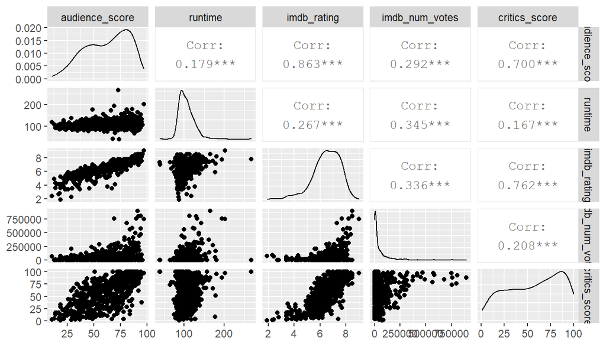

```r
ggpairs(movies_set, columns = c(1:5))
```

There are strong correleation between audience_score and imdb_rating. And critics_score also show strong correlation with audience_score. However There are strong correleation between imdb_rating and critics_score. Therefore, I just choose imdb_rating which shows stronger correlation with audience_score and drop the critics_score due to collinearity.

**Check relationship among date(period) variables**

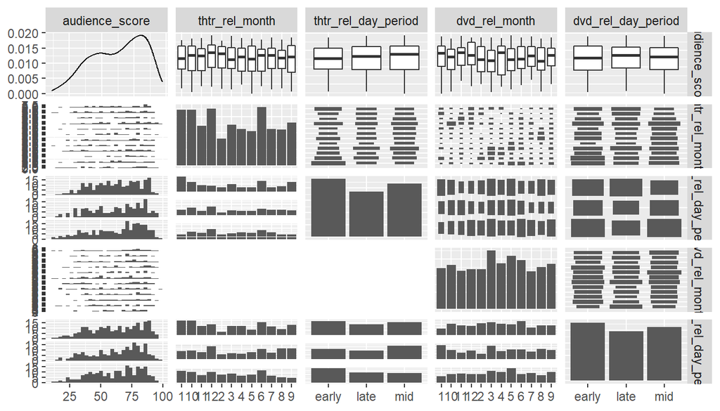

```r
ggpairs(movies_set, columns = c(1,6:9))
```

These are relationship among month, period and audience_score.

**Check relationship among categorical variables**

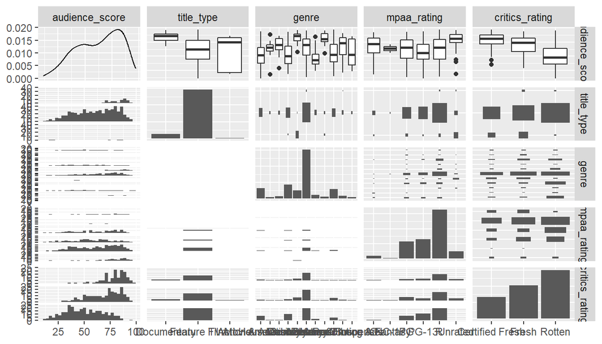

```r
ggpairs(movies_set, columns = c(1,10:13))
```

These are relationship among title_type, genre, mpaa_rating, critics_rating and audience_score.

**Check relationship among categorical variables (Yes or No)**

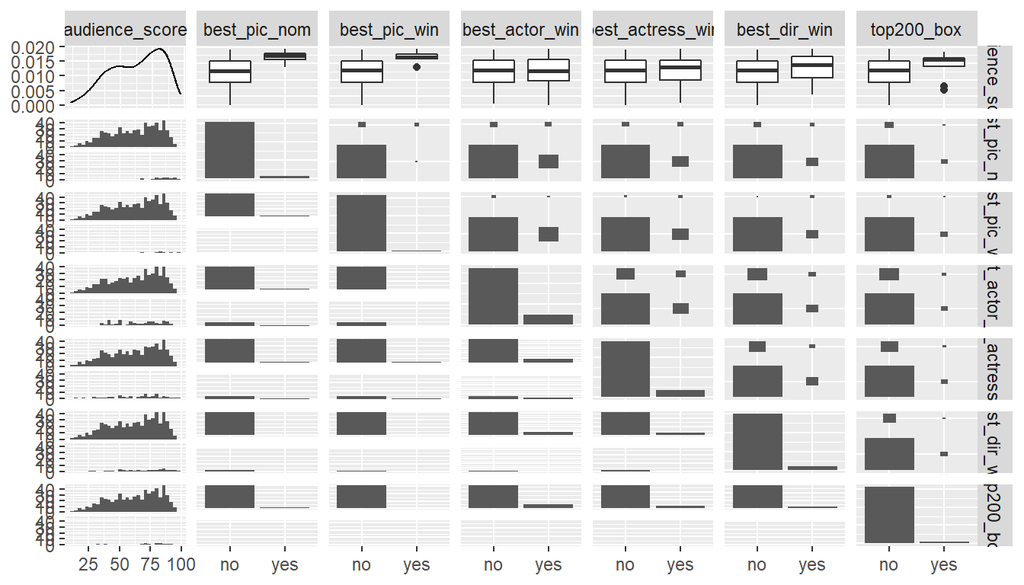

```r
ggpairs(movies_set, columns = c(1,14:19))
```

These are relationship between nomination and audience_score.

## Part 4: Modeling

**Start to build muliple regression model**

```r
movies_score_1 <- lm(audience_score ~ runtime + imdb_rating + imdb_num_votes + critics_score +
                   thtr_rel_month + thtr_rel_day_period + dvd_rel_month + dvd_rel_day_period +
                   title_type + genre + mpaa_rating + critics_rating +
                   best_pic_nom + best_pic_win + best_actor_win +
                   best_actress_win + best_dir_win + top200_box, data = movies_set)
summary(movies_score_1)
```

```
##
## Call:
## lm(formula = audience_score ~ runtime + imdb_rating + imdb_num_votes +
##     critics_score + thtr_rel_month + thtr_rel_day_period + dvd_rel_month +
##     dvd_rel_day_period + title_type + genre + mpaa_rating + critics_rating +
##     best_pic_nom + best_pic_win + best_actor_win + best_actress_win +
##     best_dir_win + top200_box, data = movies_set)
##
## Residuals:
##     Min      1Q  Median      3Q     Max
## -26.111  -6.130   0.258   5.559  47.756
##
## Coefficients:
##                                  Estimate Std. Error t value Pr(>|t|)
## (Intercept)                    -2.901e+01  6.711e+00  -4.323 1.81e-05 ***
## runtime                        -2.552e-02  2.546e-02  -1.002  0.31668
## imdb_rating                     1.515e+01  6.474e-01  23.407  < 2e-16 ***
## imdb_num_votes                  1.745e-06  4.730e-06   0.369  0.71233
## critics_score                   1.217e-04  3.691e-02   0.003  0.99737
## thtr_rel_month10               -2.270e+00  1.767e+00  -1.285  0.19938
## thtr_rel_month11               -1.064e+00  1.991e+00  -0.534  0.59333
## thtr_rel_month12               -2.255e+00  1.826e+00  -1.235  0.21736
## thtr_rel_month2                 3.315e-01  2.147e+00   0.154  0.87735
## thtr_rel_month3                -1.840e+00  1.940e+00  -0.949  0.34318
## thtr_rel_month4                -8.550e-01  1.986e+00  -0.430  0.66706
## thtr_rel_month5                 1.467e+00  2.026e+00   0.724  0.46918
## thtr_rel_month6                 6.618e-01  1.784e+00   0.371  0.71085
## thtr_rel_month7                -4.764e-01  2.008e+00  -0.237  0.81258
## thtr_rel_month8                -2.601e+00  2.016e+00  -1.290  0.19747
## thtr_rel_month9                -2.164e+00  1.896e+00  -1.141  0.25425
## thtr_rel_day_periodlate         9.173e-01  1.017e+00   0.902  0.36745
## thtr_rel_day_periodmid         -4.378e-01  9.950e-01  -0.440  0.66013
## dvd_rel_month10                -5.222e+00  2.087e+00  -2.503  0.01259 *
## dvd_rel_month11                -5.489e+00  2.147e+00  -2.557  0.01081 *
## dvd_rel_month12                -2.787e+00  2.069e+00  -1.347  0.17854
## dvd_rel_month2                 -5.294e+00  2.088e+00  -2.536  0.01148 *
## dvd_rel_month3                 -4.523e+00  1.945e+00  -2.326  0.02038 *
## dvd_rel_month4                 -3.749e+00  2.064e+00  -1.817  0.06980 .
## dvd_rel_month5                 -5.255e+00  1.969e+00  -2.669  0.00781 **
## dvd_rel_month6                 -2.957e+00  2.001e+00  -1.477  0.14016
```

[output cut: 21 more lines]

```
## mpaa_ratingUnrated              1.974e+00  3.279e+00   0.602  0.54735
## critics_ratingFresh            -1.782e+00  1.290e+00  -1.381  0.16769
## critics_ratingRotten           -4.425e+00  2.043e+00  -2.166  0.03071 *
## best_pic_nomyes                 5.961e+00  2.682e+00   2.222  0.02666 *
## best_pic_winyes                -5.163e+00  4.688e+00  -1.101  0.27124
## best_actor_winyes              -1.293e+00  1.209e+00  -1.070  0.28526
## best_actress_winyes            -2.135e+00  1.332e+00  -1.603  0.10949
## best_dir_winyes                -7.455e-01  1.735e+00  -0.430  0.66766
## top200_boxyes                   9.920e-01  2.819e+00   0.352  0.72504
## ---
## Signif. codes:  0 '***' 0.001 '**' 0.01 '*' 0.05 '.' 0.1 ' ' 1
##
## Residual standard error: 9.832 on 585 degrees of freedom
## Multiple R-squared:  0.7826, Adjusted R-squared:  0.7622
## F-statistic: 38.29 on 55 and 585 DF,  p-value: < 2.2e-16
```

For model selection, I will choose backwards elimination using the adjusted R squared method. And I will remove “critics_score” first.

**Backwards elimination - adjusted R squared method**

```r
movies_score_2 <- lm(audience_score ~ runtime + imdb_rating + imdb_num_votes +
                       thtr_rel_month + thtr_rel_day_period + dvd_rel_month + dvd_rel_day_period +
                       title_type + genre + mpaa_rating + critics_rating +
                       best_pic_nom + best_pic_win + best_actor_win +
                       best_actress_win + best_dir_win + top200_box, data = movies_set)
summary(movies_score_1)
```

[output not shown]

[output cut: 21 more lines]

```
## mpaa_ratingUnrated              1.974e+00  3.279e+00   0.602  0.54735
## critics_ratingFresh            -1.782e+00  1.290e+00  -1.381  0.16769
## critics_ratingRotten           -4.425e+00  2.043e+00  -2.166  0.03071 *
## best_pic_nomyes                 5.961e+00  2.682e+00   2.222  0.02666 *
## best_pic_winyes                -5.163e+00  4.688e+00  -1.101  0.27124
## best_actor_winyes              -1.293e+00  1.209e+00  -1.070  0.28526
## best_actress_winyes            -2.135e+00  1.332e+00  -1.603  0.10949
## best_dir_winyes                -7.455e-01  1.735e+00  -0.430  0.66766
## top200_boxyes                   9.920e-01  2.819e+00   0.352  0.72504
## ---
## Signif. codes:  0 '***' 0.001 '**' 0.01 '*' 0.05 '.' 0.1 ' ' 1
##
## Residual standard error: 9.832 on 585 degrees of freedom
## Multiple R-squared:  0.7826, Adjusted R-squared:  0.7622
## F-statistic: 38.29 on 55 and 585 DF,  p-value: < 2.2e-16
```

I can repeat removing each one of the variables one at a time until none of these options actually yield an increased adjusted R squared.

**Model selection**

```r
movies_score_12 <- lm(audience_score ~ runtime + imdb_rating +
                       dvd_rel_month +
                       genre + critics_rating +
                       best_pic_nom  +
                       best_actress_win, data = movies_set)
summary(movies_score_12)
```

```
##
## Call:
## lm(formula = audience_score ~ runtime + imdb_rating + dvd_rel_month +
##     genre + critics_rating + best_pic_nom + best_actress_win,
##     data = movies_set)
##
## Residuals:
##     Min      1Q  Median      3Q     Max
## -25.630  -6.365  -0.019   5.232  47.567
##
## Coefficients:
##                                 Estimate Std. Error t value Pr(>|t|)
## (Intercept)                    -25.56073    4.32550  -5.909  5.7e-09 ***
## runtime                         -0.03981    0.02269  -1.755 0.079783 .
## imdb_rating                     15.07507    0.51703  29.157  < 2e-16 ***
## dvd_rel_month10                 -3.43350    1.96044  -1.751 0.080378 .
## dvd_rel_month11                 -4.18433    2.01703  -2.075 0.038449 *
## dvd_rel_month12                 -1.86784    1.98771  -0.940 0.347745
## dvd_rel_month2                  -5.07778    2.01326  -2.522 0.011916 *
## dvd_rel_month3                  -4.11787    1.83718  -2.241 0.025357 *
## dvd_rel_month4                  -3.19310    1.95302  -1.635 0.102572
## dvd_rel_month5                  -4.29074    1.86900  -2.296 0.022027 *
## dvd_rel_month6                  -1.84230    1.90053  -0.969 0.332747
## dvd_rel_month7                  -2.34144    2.04815  -1.143 0.253402
## dvd_rel_month8                  -4.19552    1.98619  -2.112 0.035061 *
## dvd_rel_month9                  -1.00547    1.95166  -0.515 0.606609
## genreAnimation                   9.28756    3.54427   2.620 0.008999 **
## genreArt House & International  -0.58904    3.01783  -0.195 0.845310
## genreComedy                      2.58107    1.64544   1.569 0.117253
## genreDocumentary                 1.28987    2.02765   0.636 0.524922
## genreDrama                       0.40242    1.40661   0.286 0.774905
## genreHorror                     -4.80745    2.40406  -2.000 0.045971 *
## genreMusical & Performing Arts   4.50381    3.15276   1.429 0.153649
## genreMystery & Suspense         -5.48390    1.82535  -3.004 0.002771 **
## genreOther                       1.49734    2.77511   0.540 0.589696
## genreScience Fiction & Fantasy  -1.55123    3.70014  -0.419 0.675190
## critics_ratingFresh             -1.82935    1.15945  -1.578 0.115136
## critics_ratingRotten            -4.85940    1.30662  -3.719 0.000218 ***
## best_pic_nomyes                  3.82721    2.31882   1.650 0.099354 .
## best_actress_winyes             -2.01985    1.29695  -1.557 0.119896
## ---
## Signif. codes:  0 '***' 0.001 '**' 0.01 '*' 0.05 '.' 0.1 ' ' 1
##
## Residual standard error: 9.737 on 613 degrees of freedom
## Multiple R-squared:  0.7766, Adjusted R-squared:  0.7667
## F-statistic: 78.91 on 27 and 613 DF,  p-value: < 2.2e-16
```

```r
movies_score_13 <- lm(audience_score ~ runtime + imdb_rating +
                        dvd_rel_month +
                        genre + critics_rating +
                        best_pic_nom, data = movies_set)
summary(movies_score_13)
```

```
##
## Call:
## lm(formula = audience_score ~ runtime + imdb_rating + dvd_rel_month +
##     genre + critics_rating + best_pic_nom, data = movies_set)
##
## Residuals:
##     Min      1Q  Median      3Q     Max
## -25.310  -6.279   0.010   5.248  47.664
##
## Coefficients:
##                                 Estimate Std. Error t value Pr(>|t|)
## (Intercept)                    -25.10486    4.32059  -5.811    1e-08 ***
## runtime                         -0.04438    0.02252  -1.971 0.049210 *
## imdb_rating                     15.08130    0.51762  29.136  < 2e-16 ***
## dvd_rel_month10                 -3.58812    1.96019  -1.830 0.067661 .
## dvd_rel_month11                 -4.11655    2.01890  -2.039 0.041877 *
## dvd_rel_month12                 -1.83332    1.98989  -0.921 0.357248
## dvd_rel_month2                  -5.18789    2.01436  -2.575 0.010243 *
## dvd_rel_month3                  -4.07004    1.83906  -2.213 0.027257 *
## dvd_rel_month4                  -3.44427    1.94861  -1.768 0.077632 .
## dvd_rel_month5                  -4.30426    1.87114  -2.300 0.021764 *
## dvd_rel_month6                  -1.88363    1.90255  -0.990 0.322537
## dvd_rel_month7                  -2.50378    2.04787  -1.223 0.221939
## dvd_rel_month8                  -4.36257    1.98559  -2.197 0.028385 *
## dvd_rel_month9                  -1.13374    1.95219  -0.581 0.561619
## genreAnimation                   8.94507    3.54155   2.526 0.011795 *
## genreArt House & International  -0.79371    3.01847  -0.263 0.792676
## genreComedy                      2.31508    1.63845   1.413 0.158173
## genreDocumentary                 1.19238    2.02903   0.588 0.556977
## genreDrama                       0.11429    1.39601   0.082 0.934776
## genreHorror                     -4.85256    2.40668  -2.016 0.044205 *
## genreMusical & Performing Arts   4.47098    3.15635   1.417 0.157135
## genreMystery & Suspense         -5.84357    1.81278  -3.224 0.001333 **
## genreOther                       1.33093    2.77627   0.479 0.631827
## genreScience Fiction & Fantasy  -1.51976    3.70438  -0.410 0.681757
## critics_ratingFresh             -1.70261    1.15794  -1.470 0.141969
## critics_ratingRotten            -4.78604    1.30729  -3.661 0.000273 ***
## best_pic_nomyes                  3.33975    2.30026   1.452 0.147041
## ---
## Signif. codes:  0 '***' 0.001 '**' 0.01 '*' 0.05 '.' 0.1 ' ' 1
##
## Residual standard error: 9.749 on 614 degrees of freedom
## Multiple R-squared:  0.7757, Adjusted R-squared:  0.7662
## F-statistic: 81.66 on 26 and 614 DF,  p-value: < 2.2e-16
```

When I remove the best_actress_win, adjusted R squared is actually decreased. Therefore, I choose movies_score_12 as a final model, movies_model

**Final model**

```r
movies_model <- lm(audience_score ~ runtime + imdb_rating +
                     dvd_rel_month +
                     genre +  critics_rating +
                     best_pic_nom + best_actress_win , data = movies_set)
```

**Check collinearity**

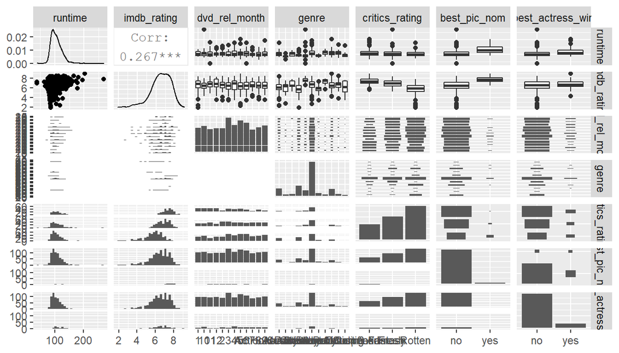

```r
movies_model_set <- movies_set %>% select(runtime, imdb_rating,
                                        dvd_rel_month,
                                        genre, critics_rating,
                                        best_pic_nom, best_actress_win)

ggpairs(movies_model_set, columns = c(1:7))
```

## Part 5: Prediction

**Set data to predict**

```r
movies_predict <- movies %>%
  filter(title == "Godzilla") %>%
  mutate(dvd_rel_month  = as.factor(as.character(dvd_rel_month))) %>%
  select(runtime, imdb_rating, dvd_rel_month, genre, critics_rating, best_pic_nom, best_actress_win)
```

**Predict the audience_score of the movie “Godzilla”**

```r
predict(movies_model, movies_predict)
```

```
##        1
## 61.04086
```

Predicted audience_score of “Godzilla” is 61.04.

**Construct a prediction interval around this prediction**

```r
predict(movies_model, movies_predict, interval = "prediction", level = 0.95)
```

```
##        fit      lwr      upr
## 1 61.04086 41.43252 80.64919
```

The model predicts, with 95% confidence, audience_score of “Godzilla” is expected between 41.43 and 80.65.

**Predicted vs. Actual audience_score**

```r
movies %>% filter(title == "Godzilla") %>% select(audience_score)
```

```
## # A tibble: 1 x 1
##   audience_score
##            <dbl>
## 1             66
```

The actual audience_score of “Godzilla” is 66 and it is wihin the model prediction.

**Diagnostics for the model**

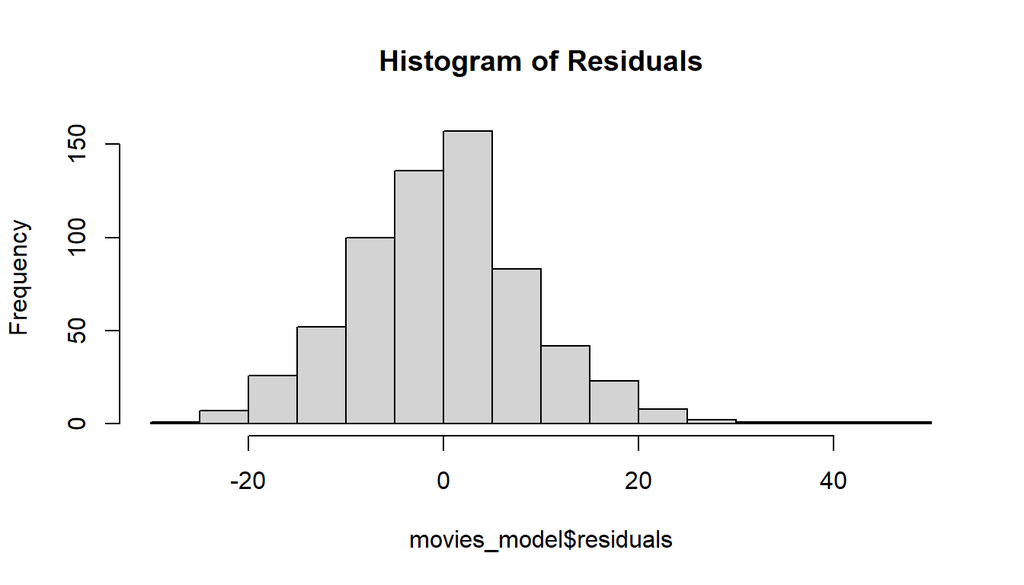

```r
hist(movies_model$residuals, main = 'Histogram of Residuals')
```

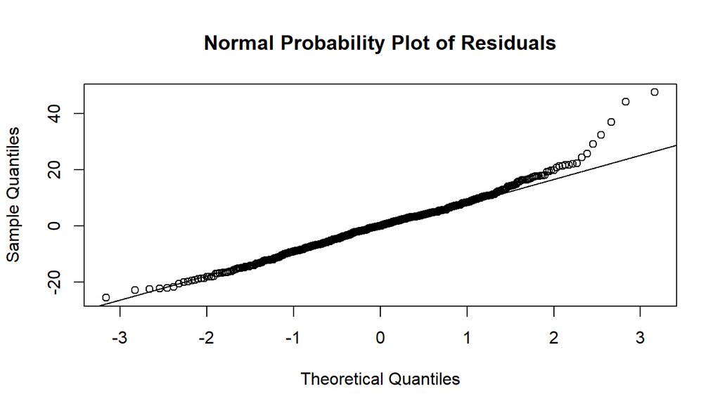

```r
qqnorm(movies_model$residuals, main = 'Normal Probability Plot of Residuals')
qqline(movies_model$residuals)
```

An observation of the histogram of residuals above show a normal distribution We see that most of the deviation occurs at the tail of the distriubtion when looking at the Q Q plot. It is clear that this is a linear distribution, so we will consider this test passed. (the expression above excerpted from Multiple regression Coursera lecture)

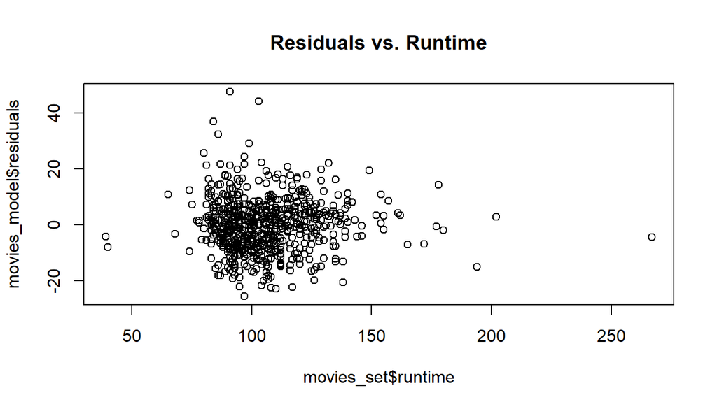

```r
plot(movies_model$residuals ~ movies_set$runtime, main = 'Residuals vs. Runtime')
```

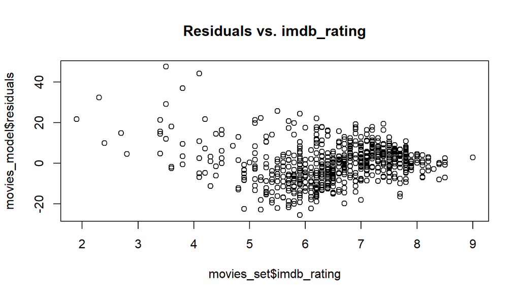

```r
plot(movies_model$residuals ~ movies_set$imdb_rating, main = 'Residuals vs. imdb_rating')
```

we want our residuals to be randomly scattered around zero. Seems like we’re somewhat meeting the condition here. (the expression above excerpted from Multiple regression Coursera lecture)

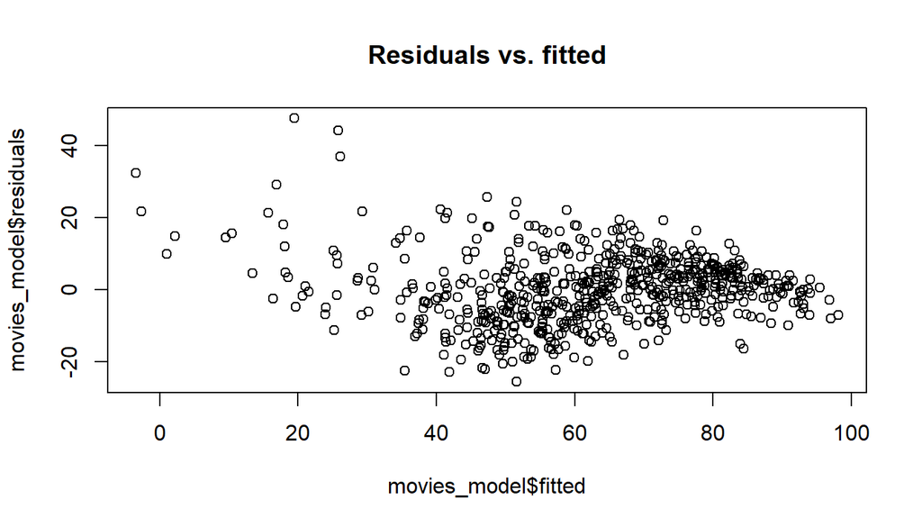

```r
plot(movies_model$residuals ~ movies_model$fitted, main = 'Residuals vs. fitted')
```

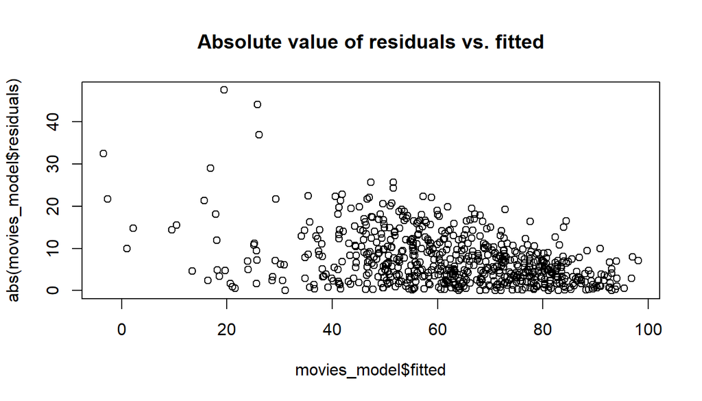

```r
plot(abs(movies_model$residuals) ~ movies_model$fitted, main = 'Absolute value of residuals vs. fitted')
```

## Part 6: Conclusion

The purpose of this research is to find out what variables have relationship with audience_score. I build a MLR and there are variables which can explain the audience_score. Those variables are runtime, imdb_rating, dvd_rel_month, genre, critics_rating, best_pic_nom, best_actress. If imdb_rating increases by 1 point, audience_score is expected to increase by 15.1 points. And if runtime increases by 1 point, audience_score is expected to decrease by 0.04 points.

Though we can not assume that there is causality, we can predict audience_score with the model roughly.

**End of the research**